# Image Captioning with Mxnet

This code is modified from [mxnet-image-caption](https://github.com/gurumurthys/mxnet-image_caption.git).

What do you see in the below picture?

[figure not shown]

Well, some of you might say "**A man is surfing on a wave**", some might say "**Surfer in the ocean riding a large wave**", and yet some others might say "**A man is riding a wave in the ocean**". All of these answers are saying the same thing with different words and different word orders. Such a task that prodices a caption given an images is called image captioning. There are several existing online services providing this API, such as [CaptionBot](https://www.captionbot.ai/) powered by [Microsoft Cognitive Service](https://azure.microsoft.com/en-us/services/cognitive-services/).

[figure not shown]

This code implements the paper, [**Show and Tell: A Neural Image Caption Generator**](https://arxiv.org/abs/1411.4555) and the model is trained on [MSCOCO](http://cocodataset.org/#captions-2015) dataset. Here, we only use the dataset of a set of images each with 1 caption and their feature vectors ($1\times2048$).

## System Versioning

- OS: Ubuntu 16.04.6 LTS
- Python: 3.5.2
- CUDA: V10.0.130
- CUDNN: 7_7.4.1.5

## Python Package Versioning

```python
import os
import cv2
import sys
import time
import urllib
import pickle
import logging
import numpy as np
import matplotlib
import matplotlib.pyplot as plt
from collections import namedtuple

import mxnet as mx
from mxnet.io import DataBatch


import types
def imports():
    for name, val in globals().items():
        if isinstance(val, types.ModuleType):
            yield val.__name__, val.__version__ if hasattr(val, '__version__') else 'NaN'
for name, version in list(imports()):
    print(name, version)

!wget -nc https://www.dropbox.com/s/vgtvff6zt15k6m4/captiondata10k.pickle?dl=1 --output-document captiondata10k.pickle
!wget -nc https://www.dropbox.com/s/dnsre7x5dxhxlfw/captiondataval10k.pickle?dl=1 --output-document captiondataval10k.pickle
```

[output not shown]

## Loading COCO Dataset

*allwords* contains all the feature vectors and their corresponding 1 caption.

Image feature vector is the output of the last layer before the fully connectted layer of [ResNet-50](https://arxiv.org/abs/1512.03385) in [Mxnet Model Zoo](https://mxnet.incubator.apache.org/api/python/gluon/model_zoo.html). There are total 16 residual blocks, 1 shortcut connection and 3 convolution layers in each block as shown below.

[figure not shown]

A caption is a list of word indices. **< S >** is the start of a sentence and **< \S >** is the end of a sentence.

*allindexes* is the indices of all images.

*vocabwords* is the dictionary from word to id.

*vocabids* is the dictionary from id to word.

```python
with open('captiondata10k.pickle', 'rb') as f:
    [allwords, allindexes, vocabwords, vocabids, _] = pickle.load(f, encoding='latin1')

key = list(allwords.keys())[0]
print('feature vector: ', allwords[key][0])
print('caption indexes: ', allwords[key][1])
print('imgid: ', allindexes[key])
key = list(vocabwords.keys())[0]
print('word -> index: ', key, '->', vocabwords[key])
key = list(vocabids.keys())[0]
print('index -> word: ', key, '->', vocabids[key])

words = []
for key in allwords[key][1]:
    words.append(vocabids[key])
print('caption word: ', words)
```

```
feature vector:  [[0.23896003 0.         0.9243923  ... 0.42736265 0.5047168  1.5080156 ]]
caption indexes:  [1, 19, 1019, 7, 14, 133, 490, 81, 211, 3, 2]
imgid:  262145
word -> index:  curtained -> 4550
index -> word:  0 -> a
caption word:  ['<S>', 'people', 'shopping', 'in', 'an', 'open', 'market', 'for', 'vegetables', '.', '</S>']
```

## LSTM cell and LSTM network

*i2h* is the fully connected layer from input $x_t$ to the gates.

*h2h* is the fully connected layer from previous hidden state $h_{t-1}$ to the gates.

There are 4 gates (forget gate *forget_gate*, input gate *in_gate*, output gate *out_gate*, and candidate memory *in_transformation*).

This is an illustration of a LSTM cell.

[figure not shown]

```python
'''
module that defines lstm network that is used for image captioning
'''

LSTMState = namedtuple("LSTMState", ["c", "h"])
LSTMParam = namedtuple("LSTMParam", ["i2h_weight", "i2h_bias",
                                     "h2h_weight", "h2h_bias"])
LSTMModel = namedtuple("LSTMModel", ["rnn_exec", "symbol",
                                     "init_states", "last_states",
                                     "forward_state", "backward_state",
                                     "seq_data", "seq_labels", "seq_outputs",
                                     "param_blocks"])


def lstmcell(num_hidden, indata, prev_state, param, seqidx, layeridx, dropout=0.3):
    '''
    Defines an LSTM cell
    Args:
        num_hidden: number of hidden units
        indata: input data to LSTM cell
        prev_state: previous state vector
        param: parameter for this LSTM (weights and biases)
        seqidx: sequence id
        layeridx: layer index (0 - first layer, 1 - second layer). Useful for
            bi-directional LSTM
        dropout: fraction of the input that gets dropped out during training
            time
    Returns:
        LSTM cell object
    '''
    indata = mx.sym.Dropout(data=indata, p=dropout)

    i2h = mx.sym.FullyConnected(data=indata,
                                weight=param.i2h_weight,
                                bias=param.i2h_bias,
                                num_hidden=num_hidden * 4,
                                name="t%d_l%d_i2h" % (seqidx, layeridx))
    h2h = mx.sym.FullyConnected(data=prev_state.h,
                                weight=param.h2h_weight,
                                bias=param.h2h_bias,
                                num_hidden=num_hidden * 4,
                                name="t%d_l%d_h2h" % (seqidx, layeridx))
    gates = i2h + h2h
    slice_gates = mx.sym.SliceChannel(gates, num_outputs=4,
                                      name="t%d_l%d_slice" %
                                      (seqidx, layeridx))
    in_gate = mx.sym.Activation(slice_gates[0], act_type="sigmoid")
    in_transform = mx.sym.Activation(slice_gates[1], act_type="tanh")
    forget_gate = mx.sym.Activation(slice_gates[2], act_type="sigmoid")
    out_gate = mx.sym.Activation(slice_gates[3], act_type="sigmoid")
    next_c = (forget_gate * prev_state.c) + (in_gate * in_transform)
    next_h = out_gate * next_c

    return LSTMState(c=next_c, h=next_h)

def build_lstm_network(seq_len, input_size, num_hidden, num_embed, num_label,
                       prediction=False):
    '''
    Build the LSTM network
    Args:
        seq_len: length of the sequence - number of times to unroll
        input_size: input vector dimension
        num_hidden: number of hiddent units
        num_embed: output dimension for the embedding unit
        num_label: output dimension for the fully-connected unit
        prediction: True if used for prediction, False if for training
    Returns:
        LSTM network symbol
    '''
    embed_weight = mx.sym.Variable("embed_weight")
    cls_weight = mx.sym.Variable("cls_weight")
    cls_bias = mx.sym.Variable("cls_bias")

    # input image feature vector
    data = mx.sym.Variable('data')
    # word indices
    label = mx.sym.Variable('softmax_label')
    # one-hot encoding of word indices
    veclabel = mx.sym.Variable('veclabel')
    # veclabel = mx.sym.Reshape(veclabel, shape=(-1, seq_len)) # https://github.com/apache/incubator-mxnet/issues/7178

    name = 'l0'
    param = LSTMParam(i2h_weight=mx.sym.Variable(name+"_i2h_weight"),
                      i2h_bias=mx.sym.Variable(name+"_i2h_bias"),
                      h2h_weight=mx.sym.Variable(name+"_h2h_weight"),
                      h2h_bias=mx.sym.Variable(name+"_h2h_bias"))
    lstm_state = LSTMState(c=mx.sym.Variable(name+"_init_c"),
                           h=mx.sym.Variable(name+"_init_h"))
    allsm = []
    # label indices
    labelidx = mx.sym.SliceChannel(data=label, num_outputs=seq_len,
                                   squeeze_axis=1)
    # label one-hot vector
    labelvec = mx.sym.SliceChannel(data=veclabel, num_outputs=seq_len,
                                   squeeze_axis=1)
    output = ''
    targetlen = seq_len
    if prediction:
        # increase seq_len to generate till stop words during testing
        # it is a hack for now
        targetlen = seq_len + 10
    for seqidx in range(targetlen):
        k = seqidx
        # testing may use more than seq_len, hence reuse the last input
        # as dummy labels for softmax
        if k >= seq_len:
            k = seq_len - 1
        # first iteration use image feature as input
        if k == 0:
            hidden = data
        else:
            # if in prediction mode and not in first iteration use the
            # system output generated in previous timestep as input
            if prediction & (k > 1):
                embed = mx.sym.Embedding(data=output,
                                         input_dim=input_size,
                                         weight=embed_weight,
                                         output_dim=num_embed, name='embed')
            else:
                embed = mx.sym.Embedding(data=labelvec[k-1],
                                         input_dim=input_size,
                                         weight=embed_weight,
                                         output_dim=num_embed, name='embed')
            hidden = embed

        next_state = lstmcell(num_hidden, indata=hidden,
                              prev_state=lstm_state,
                              param=param, seqidx=k, layeridx=0)
        hidden = next_state.h
        lstm_state = next_state
        if k == 0:
            continue
        pred = mx.sym.FullyConnected(data=hidden, num_hidden=num_label,
                                     weight=cls_weight,
                                     bias=cls_bias, name='pred')
        softmax_output = mx.sym.SoftmaxOutput(data=pred, label=labelidx[k],
                                              name='softmax')
        output = mx.sym.argmax(softmax_output, axis=1)
        allsm.append(softmax_output)

    allsm = mx.sym.Concat(*allsm, dim=1)
    softmax_output = mx.sym.reshape(allsm, shape=(-1, num_label))
    return (softmax_output,
            ['veclabel', 'l0_init_h', 'l0_init_c', 'data'],
            ['softmax_label'])
```

## Bucketing in Mxnet

When training a recurrent neural network (RNN), we unroll the network in time. For a single example of length T, we would unroll the network T steps. In the unrolled view, the weights are shared across times steps. The unrolled view allows us to train the network via backpropagation (*backpropagation through time*).

However, there are varying lengths of sequences in a dataset. In the unrolled view, each example requires a different number of unrollings. If we want to perform mini-batch training, we will have to pad all the sequences so they have the same length as the longest example. This could be wastful bacause on shorter sequences, most of the computations are done on padded data.

Bucketing offers an effective solution to make minibatches out of varying-length sequences. Instead of unrolling the network to the maximum possible sequence length, we unroll multiple instances of different lengths (e.g., length 5, 10, 20, 30).

The function *default_gen_buckets* will generate a list of buckets based on the set of captions in the input. This list will contain the sizes of each bucket.

```python
'''
module that defines bucketing data iter
'''

def default_gen_buckets(allwords, batch_size):
    '''
    Generate buckets based on data. This method generates a list of buckets
    and the length of those buckets based on the input
    Args:
        allwords: all the sentences (set of words) that are part of the data
        batch_size: batch size to check if a particular bucket has that many
        elements
    Returns:
        returns the generated buckets
    '''
    len_dict = {}
    max_len = -1
    for key in allwords:
        words = allwords[key][1]
        if len(words) == 0:
            continue
        if len(words) > max_len:
            max_len = len(words)
        if len(words) in len_dict:
            len_dict[len(words)] += 1
        else:
            len_dict[len(words)] = 1
    buckets = []
    for length, num in len_dict.items():
        if num >= batch_size:
            buckets.append(length)

    return buckets

class BucketIter(mx.io.DataIter):
    '''
    Class that defines the data iter for image captioning module
    '''
    def __init__(self, captionf, batch_size=1):
        '''
        Init function for the class
        Args:
            captionf: pickle filename that has all the captions
            batch_size: batch size for training data
        '''
        super(BucketIter, self).__init__()
        self.batch_size = batch_size

        # load datafiles, ignore the second output which is just the img ids
        # for each data element - used in case we need access to img id during
        # testing
        [self.allwords, _, self.vocabwords, self.vocabids, \
         self.unknown_id] = pickle.load(open(captionf, 'rb'), encoding='latin1')

        # generate buckets
        buckets = default_gen_buckets(self.allwords, batch_size)
        buckets.sort()
        self.buckets = buckets
        # assing default bucket - ideally should be the largest bucket
        self.default_bucket_key = max(buckets)

        # Assign data to their corresponding bucket
        self.databkt = [[] for _ in buckets]
        self.cursor = {}
        self.num_data_bkt = {}
        for idx in self.allwords:
            strs = self.allwords[idx][1]
            for i, bkt in enumerate(buckets):
                if bkt == len(strs):
                    self.databkt[i].append(idx)
                    break

        # initialize bucket specific parameters, the current index into
        # the bucket and the remaining number of elements in the bucket
        for i, bkt in enumerate(buckets):
            self.cursor[i] = -1
            self.num_data_bkt[i] = len(self.databkt[i])

        # iterator variables
        self.epoch = 0
        self.bidx = np.argmax(buckets)
        self.data, self.label = self.read(self.bidx)
        self.reset()

    @property
    def bucket_key(self):
        '''
        bucket key for bucketiter module
        '''
        return self.buckets[self.bidx]

    @property
    def provide_data(self):
        """The name and shape of data provided by this iterator"""
        # res = [(k, tuple(list(self.data[k].shape[0:]))) for k in self.data]
        res = [('veclabel', tuple(list(self.data['veclabel'].shape[0:]))),
               ('l0_init_h', tuple(list(self.data['l0_init_h'].shape[0:]))),
               ('l0_init_c', tuple(list(self.data['l0_init_c'].shape[0:]))),
               ('data', tuple(list(self.data['data'].shape[0:])))]
        return res

    @property
    def provide_label(self):
        """The name and shape of label provided by this iterator"""
        res = [(k, tuple(list(self.label[k].shape[0:]))) for k in self.label]
        return res

    def reset(self):
        '''
        data iter reset
        '''
        for index, _ in enumerate(self.cursor):
            self.cursor[index] = -1
        self.epoch += 1

    def next(self):
        """return one dict which contains "data" and "label" """
        if self.iter_next():
            # select one random bucket out of all the ones that has
            # > batch_size remaining samples
            rem = [i for i, _ in enumerate(self.buckets)
                   if (len(self.databkt[i])-self.cursor[i]) > self.batch_size]
            bidx = np.random.randint(0, len(rem))
            bidx = rem[bidx]
            # read the samples from the bucket
            self.data, self.label = self.read(bidx)
            # prepare as databatch to return
            res = DataBatch(provide_data=self.provide_data,
                            provide_label=self.provide_label,
                            bucket_key=self.buckets[self.bidx],
                            data=[mx.nd.array(self.data['veclabel']),
                                  mx.nd.array(self.data['l0_init_h']),
                                  mx.nd.array(self.data['l0_init_c']),
                                  mx.nd.array(self.data['data'])],
                            label=[mx.nd.array(self.label['softmax_label'])],
                            pad=0, index=None)
            return res
        else:
            raise StopIteration

    def iter_next(self):
        '''
        check if next iteration can be done
        '''
        for i, _ in enumerate(self.buckets):
            if self.cursor[i] + self.batch_size < self.num_data_bkt[i]:
                return True
        return False

    def read(self, bidx):
        '''
        read the next set of data based on bucket index
        Args:
            bidx: bucket index
        '''
        self.bidx = bidx
        data_array = []
        allimgids = []
        label = []
        labelvec = []
        index = 0
        while 1:
            self.cursor[bidx] += 1
            # obtain the feature vector
            data = self.get_data(bidx)
            # obtain the label (caption word indices)
            labels = self.get_label(bidx)
            if len(labels) == 0:
                continue
            data_array.append(data)
            # construct a one-hot vector of labels
            labela = []
            labelveca = []
            for labelidx in labels:
                labelarray = np.zeros((len(self.vocabwords)+1), dtype='int')
                labelarray[labelidx] = 1
                labela.append(labelarray)
                labelveca.append(labelidx)
            label.append(labela)
            labelvec.append(labelveca)
            index += 1
            if index > (self.batch_size-1):
                break

        darray = np.vstack(data_array)
        # this is also defined in training code - need to set the same number
        # of hidden units for the LSTM
        num_hidden = 512

        data = {}
        data['l0_init_h'] = np.zeros((darray.shape[0], num_hidden),
                                     dtype='float')
        data['l0_init_c'] = np.zeros((darray.shape[0], num_hidden),
                                     dtype='float')
        data['data'] = darray
        data['veclabel'] = np.array(labelvec)

        finallabel = {}
        finallabel['softmax_label'] = np.asarray(label)

        return (data, finallabel)

    def get_data(self, bidx):
        '''
        Returns the feature vector based on the current cursor
        and bucket index
        Args:
            bidx: bucket index
        '''
        idx = self.databkt[bidx][self.cursor[bidx]]
        return self.allwords[idx][0]

    def get_label(self, bidx):
        '''
        Returns the label vector based on the current cursor
        and bucket index
        Args:
            bidx: bucket index
        '''
        idx = self.databkt[bidx][self.cursor[bidx]]
        return self.allwords[idx][1]
```

```python
'''
main code for training image captioning model
'''

DEBUG = True

def custommetric(label, pred):
    '''
    Simple metric that outputs the fraction of correct word predictions
    to the total number of words
    Args:
        label: ground truth label
        pred: predicted output
    Returns:
        accuracy metric
    '''
    # shift by one word to match prediction
    label = label[:, 1:, :]

    pred = np.reshape(pred, label.shape)
    label = np.argmax(label, axis=2)
    pred = np.argmax(pred, axis=2)
    return float(np.sum(pred == label)) / np.sum(label >= 0)
```

```python
BATCH_SIZE = 192
NUM_HIDDEN = 512
NUM_EPOCH = 96
GENERATE_GRAPH = False
DATADIR = '.'

data_train = BucketIter(DATADIR+'/captiondata10k.pickle',
                        batch_size=BATCH_SIZE)
if DEBUG:
    print('training data loaded ....')
    print('provide data', data_train.provide_data, 'provide label', data_train.provide_label, 'default bucket key', data_train.default_bucket_key)

for i in range(len(data_train.provide_data)): # TODO: returned list didn't guarantee sequence
    if data_train.provide_data[i][0] == 'data':
        INPUT_SIZE = data_train.provide_data[i][1][1]
        EMBED_SIZE = data_train.provide_data[i][1][1]
        break

NUM_LABEL = len(data_train.vocabwords)+1
if DEBUG:
    print('input size', INPUT_SIZE, 'number label', NUM_LABEL, 'embed size', EMBED_SIZE)

data_val = BucketIter(DATADIR+'/captiondataval10k.pickle',
                      batch_size=BATCH_SIZE)
if DEBUG:
    print('validation data loaded ....')
```

```
training data loaded ....
provide data [('veclabel', (192, 16)), ('l0_init_h', (192, 512)), ('l0_init_c', (192, 512)), ('data', (192, 2048))] provide label [('softmax_label', (192, 16, 9955))] default bucket key 16
input size 2048 number label 9955 embed size 2048
validation data loaded ....
```

```python
contexts = mx.gpu(3) # [mx.context.gpu(i) for i in range(1)]

# this is needed for the bucketing module
def sym_gen(seq_len):
    '''
    needed for bucketing module, network generated based on seq_len
    Args:
        seq_len: length of the current sequence
    Returns:
        Symbolic network
    '''
    return build_lstm_network(seq_len, INPUT_SIZE, NUM_HIDDEN, EMBED_SIZE,
                              NUM_LABEL)

model = mx.mod.BucketingModule(sym_gen, data_train.default_bucket_key,
                               context=contexts)

model.bind(data_shapes=data_train.provide_data,
           label_shapes=data_train.provide_label)
model.init_params(initializer=mx.init.Normal(sigma=0.01))

head = '%(asctime)-15s %(message)s'
logging.basicConfig(level=logging.INFO, format=head)
```

```python
start_time = time.time()
if not os.path.exists('models'):
    os.mkdir('models')
CHECKPOINT_NAME = 'models/imagecaption'

model.fit(data_train, data_val, num_epoch=NUM_EPOCH, optimizer='adam',
              optimizer_params={'learning_rate': 1e-3},
              eval_metric=mx.metric.CustomMetric(custommetric),
              epoch_end_callback=mx.callback.do_checkpoint(CHECKPOINT_NAME))
print('program run time', time.time() - start_time)
```

```
2019-09-07 19:48:35,546 Already bound, ignoring bind()
2019-09-07 19:48:52,736 Epoch[0] Train-custommetric=0.095028
2019-09-07 19:48:52,738 Epoch[0] Time cost=17.189
2019-09-07 19:48:52,873 Saved checkpoint to "models/imagecaption-0001.params"
2019-09-07 19:49:04,640 Epoch[0] Validation-custommetric=0.090923
2019-09-07 19:49:20,491 Epoch[1] Train-custommetric=0.100061
2019-09-07 19:49:20,494 Epoch[1] Time cost=15.853
2019-09-07 19:49:20,641 Saved checkpoint to "models/imagecaption-0002.params"
2019-09-07 19:49:31,687 Epoch[1] Validation-custommetric=0.132261
2019-09-07 19:49:46,886 Epoch[2] Train-custommetric=0.204603
2019-09-07 19:49:46,888 Epoch[2] Time cost=15.199
2019-09-07 19:49:47,042 Saved checkpoint to "models/imagecaption-0003.params"
2019-09-07 19:49:58,109 Epoch[2] Validation-custommetric=0.233189
2019-09-07 19:50:13,786 Epoch[3] Train-custommetric=0.229237
2019-09-07 19:50:13,788 Epoch[3] Time cost=15.677
2019-09-07 19:50:13,894 Saved checkpoint to "models/imagecaption-0004.params"
2019-09-07 19:50:25,476 Epoch[3] Validation-custommetric=0.232909
2019-09-07 19:50:41,643 Epoch[4] Train-custommetric=0.230587
2019-09-07 19:50:41,645 Epoch[4] Time cost=16.168
2019-09-07 19:50:41,875 Saved checkpoint to "models/imagecaption-0005.params"
2019-09-07 19:50:52,908 Epoch[4] Validation-custommetric=0.234601
2019-09-07 19:51:08,462 Epoch[5] Train-custommetric=0.258921
2019-09-07 19:51:08,464 Epoch[5] Time cost=15.554
2019-09-07 19:51:08,657 Saved checkpoint to "models/imagecaption-0006.params"
2019-09-07 19:51:20,095 Epoch[5] Validation-custommetric=0.266079
2019-09-07 19:51:35,581 Epoch[6] Train-custommetric=0.287649
2019-09-07 19:51:35,583 Epoch[6] Time cost=15.486
2019-09-07 19:51:35,669 Saved checkpoint to "models/imagecaption-0007.params"
2019-09-07 19:51:47,259 Epoch[6] Validation-custommetric=0.302300
2019-09-07 19:52:02,973 Epoch[7] Train-custommetric=0.312567
2019-09-07 19:52:02,975 Epoch[7] Time cost=15.714
2019-09-07 19:52:03,075 Saved checkpoint to "models/imagecaption-0008.params"
2019-09-07 19:52:13,864 Epoch[7] Validation-custommetric=0.313838
2019-09-07 19:52:29,513 Epoch[8] Train-custommetric=0.322670
2019-09-07 19:52:29,516 Epoch[8] Time cost=15.650
2019-09-07 19:52:29,604 Saved checkpoint to "models/imagecaption-0009.params"
2019-09-07 19:52:40,661 Epoch[8] Validation-custommetric=0.323770
2019-09-07 19:52:56,275 Epoch[9] Train-custommetric=0.335742
2019-09-07 19:52:56,277 Epoch[9] Time cost=15.614
2019-09-07 19:52:56,399 Saved checkpoint to "models/imagecaption-0010.params"
```

[output cut: 330 more lines]

```
2019-09-07 20:30:21,618 Epoch[92] Time cost=20.070
2019-09-07 20:30:22,497 Saved checkpoint to "models/imagecaption-0093.params"
2019-09-07 20:30:35,458 Epoch[92] Validation-custommetric=0.365387
2019-09-07 20:30:54,727 Epoch[93] Train-custommetric=0.913274
2019-09-07 20:30:54,731 Epoch[93] Time cost=19.269
2019-09-07 20:30:55,632 Saved checkpoint to "models/imagecaption-0094.params"
2019-09-07 20:31:09,713 Epoch[93] Validation-custommetric=0.366574
2019-09-07 20:31:29,473 Epoch[94] Train-custommetric=0.913691
2019-09-07 20:31:29,474 Epoch[94] Time cost=19.747
2019-09-07 20:31:29,608 Saved checkpoint to "models/imagecaption-0095.params"
2019-09-07 20:31:41,970 Epoch[94] Validation-custommetric=0.364529
2019-09-07 20:32:01,334 Epoch[95] Train-custommetric=0.913289
2019-09-07 20:32:01,336 Epoch[95] Time cost=19.348
2019-09-07 20:32:02,036 Saved checkpoint to "models/imagecaption-0096.params"
2019-09-07 20:32:15,758 Epoch[95] Validation-custommetric=0.366743
```

```
program run time 2620.220703601837
```

## Test the model to generate a caption

```python
'''
module that generates features for images using resnet
'''

Batch = namedtuple('Batch', ['data'])


def download(url):
    '''
    download the file given the url
    Args:
        url: path for the filename
    '''
    filename = url.split("/")[-1]
    if not os.path.exists(filename):
        urllib.request.urlretrieve(url, filename)


def get_model(prefix, epoch):
    '''
    get the model with prefix and epoch
    Args:
        prefix: model prefix
        epoch: trained model - epoch
    '''
    download(prefix+'-symbol.json')
    download(prefix+'-%04d.params' % (epoch,))


def get_image(filename):
    '''
    return the image based on filename after resizing it to 224x224 to be
    fit for reset format
    Args:
        filename: filename of the image
    '''
    img = cv2.imread(filename)  # read image in b,g,r order
    img = cv2.cvtColor(img, cv2.COLOR_BGR2RGB)   # change to r,g,b order
    img = cv2.resize(img, (224, 224))  # resize to 224*224 to fit model
    img = np.swapaxes(img, 0, 2)
    img = np.swapaxes(img, 1, 2)  # change to (channel, height, width)
    img = img[np.newaxis, :]  # extend to (example, channel, heigth, width)
    return img


class Resnet(object):
    '''
    Resnet class to construct reset model object
    '''
    def __init__(self):
        '''
        Download the model from mxnet database and constructs the network
        for prediction
        '''
        url = 'http://data.mxnet.io/models/imagenet/resnet/50-layers/resnet-50'
        get_model(url, 0)
        sym, arg_params, aux_params = mx.model.load_checkpoint('resnet-50', 0)
        all_layers = sym.get_internals()
        sym3 = all_layers['flatten0_output']
        mod3 = mx.mod.Module(symbol=sym3, label_names=None, context=mx.cpu())
        mod3.bind(for_training=False, data_shapes=[('data', (1, 3, 224, 224))])
        mod3.set_params(arg_params, aux_params)
        self.mod3 = mod3

    def gen_features(self, img_path):
        '''
        generate features given an image
        Args:
            img_path: full path to the image
        '''
        img = get_image(img_path)
        self.mod3.forward(Batch([mx.nd.array(img)]))
        return self.mod3.get_outputs()[0].asnumpy()


def get_feature(imgfname):
    '''
    Returns the feature for the image
    Args:
        imagefname: full path to the image
    '''
    network = Resnet()
    return network.gen_features(imgfname)
```

```
--2019-09-07 20:32:16--  https://www.dropbox.com/s/41kfb3ezigssa9q/testimage.jpg?dl=1
Resolving www.dropbox.com (www.dropbox.com)... 162.125.82.1, 2620:100:6032:1::a27d:5201
Connecting to www.dropbox.com (www.dropbox.com)|162.125.82.1|:443... connected.
HTTP request sent, awaiting response... 301 Moved Permanently
Location: /s/dl/41kfb3ezigssa9q/testimage.jpg [following]
--2019-09-07 20:32:16--  https://www.dropbox.com/s/dl/41kfb3ezigssa9q/testimage.jpg
Reusing existing connection to www.dropbox.com:443.
HTTP request sent, awaiting response... 302 Found
Location: https://uc753a5d9ed24c2da5ace20c6c3a.dl.dropboxusercontent.com/cd/0/get/AoFTMraInSdnB6_4Iu5UayD1ciRduP4srL9EKflu0I0iDh_xQTHM0D2B0s8RHIVBgbXSgPc_e5zu5MW5jo7OFWkWN_RZn4y0eOSdsfvKclHlpQ/file?dl=1# [following]
--2019-09-07 20:32:16--  https://uc753a5d9ed24c2da5ace20c6c3a.dl.dropboxusercontent.com/cd/0/get/AoFTMraInSdnB6_4Iu5UayD1ciRduP4srL9EKflu0I0iDh_xQTHM0D2B0s8RHIVBgbXSgPc_e5zu5MW5jo7OFWkWN_RZn4y0eOSdsfvKclHlpQ/file?dl=1
Resolving uc753a5d9ed24c2da5ace20c6c3a.dl.dropboxusercontent.com (uc753a5d9ed24c2da5ace20c6c3a.dl.dropboxusercontent.com)... 162.125.82.6, 2620:100:6032:6::a27d:5206
Connecting to uc753a5d9ed24c2da5ace20c6c3a.dl.dropboxusercontent.com (uc753a5d9ed24c2da5ace20c6c3a.dl.dropboxusercontent.com)|162.125.82.6|:443... connected.
HTTP request sent, awaiting response... 200 OK
Length: 200245 (196K) [application/binary]
Saving to: ‘testimage.jpg’

testimage.jpg       100%[===================>] 195.55K   468KB/s    in 0.4s

2019-09-07 20:32:17 (468 KB/s) - ‘testimage.jpg’ saved [200245/200245]

man in a cap is riding a surfboard in the ocean .
```

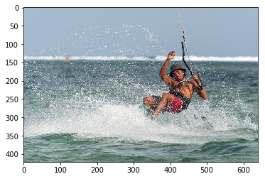

```python
'''
generate captions for an image
'''

%matplotlib inline
NUM_LSTM_LAYER = 1
BATCH_SIZE = 1

! wget -nc https://www.dropbox.com/s/41kfb3ezigssa9q/testimage.jpg?dl=1 --output-document testimage.jpg
imgfname = "testimage.jpg"

SEQ_LEN = 25

sym, arg_params, aux_params = \
    mx.model.load_checkpoint(CHECKPOINT_NAME, NUM_EPOCH)

NUM_HIDDEN = arg_params['l0_h2h_weight'].shape[1]
INPUT_SIZE = arg_params['l0_h2h_weight'].shape[0]
NUM_LABEL = arg_params['cls_weight'].shape[0]
sym, _, _ = build_lstm_network(SEQ_LEN, INPUT_SIZE, NUM_HIDDEN,
                               INPUT_SIZE, NUM_LABEL, prediction=True)

init_c = [('l%d_init_c' % l, (BATCH_SIZE, NUM_HIDDEN))
          for l in range(NUM_LSTM_LAYER)]
init_h = [('l%d_init_h' % l, (BATCH_SIZE, NUM_HIDDEN))
          for l in range(NUM_LSTM_LAYER)]
data_shape = [("data", (BATCH_SIZE, 2048))]
label_shape = [("veclabel",
                (BATCH_SIZE, SEQ_LEN, ))]
label_shape1 = [("softmax_label",
                 (BATCH_SIZE, SEQ_LEN, NUM_LABEL))]

f = get_feature(imgfname)
input_data = mx.nd.array(f)

veclabel = mx.nd.zeros((BATCH_SIZE, SEQ_LEN))
veclabel[0][0] = 0
input_shapes = dict(init_c+init_h+data_shape+label_shape+label_shape1)

executor = sym.simple_bind(ctx=mx.gpu(), **input_shapes)

for key in executor.arg_dict.keys():
    if key in arg_params:
        arg_params[key].copyto(executor.arg_dict[key])

state_name = []
for i in range(NUM_LSTM_LAYER):
    state_name.append("l%d_init_c" % i)
states_dict = dict(zip(state_name, executor.outputs[1:]))
input_arr = mx.nd.zeros(data_shape[0][1])

for key in states_dict.keys():
    executor.arg_dict[key][:] = 0.

input_data.copyto(executor.arg_dict["data"])
veclabel.copyto(executor.arg_dict["veclabel"])

executor.forward()

for key in states_dict.keys():
    states_dict[key].copyto(executor.arg_dict[key])

prob = executor.outputs[0].asnumpy()

img = cv2.imread(imgfname)[:,:,::-1]
plt.imshow(img)
# [_, _, _, vocab, _]  = pickle.load(open(VOCABF, 'r'))
for index in range(0, BATCH_SIZE):
    p = np.reshape(prob, (-1, SEQ_LEN+9, len(data_train.vocabwords)+1))
    p = np.argmax(p, axis=2)[index, :]
    str1 = ''
    index = 0
    for i in p:
        if i == 2:
            break
        str1 = str1 + data_train.vocabids[i] + ' '
        index += 1
print(str1)
```